# Time Series Analysis - ARIMA Models

Abdullahi Hussein

03/09/2021

## Exploring the data

In this article, we are going to use the USA quarterly GDP available in **astsa** library in R. We will start with loading the required libraries and the data.

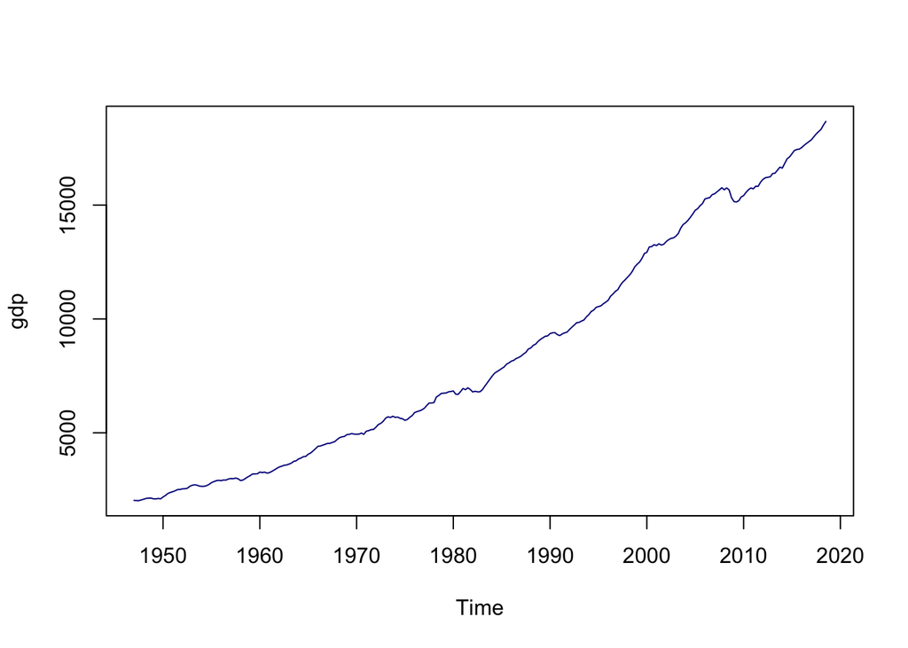

```r
# if library not installed use
# install.packages("astsa")
# loading the library
library(astsa)
#loading the data
data(gdp)
#plotting the data. This is a time series data so we use the appropriate plots
plot.ts(gdp, col = "darkblue")
```

The the above plot we see that Y-axis values are two large. This means, our data is skewed. Since, the data is skewed and all positive, we can use log transformation.

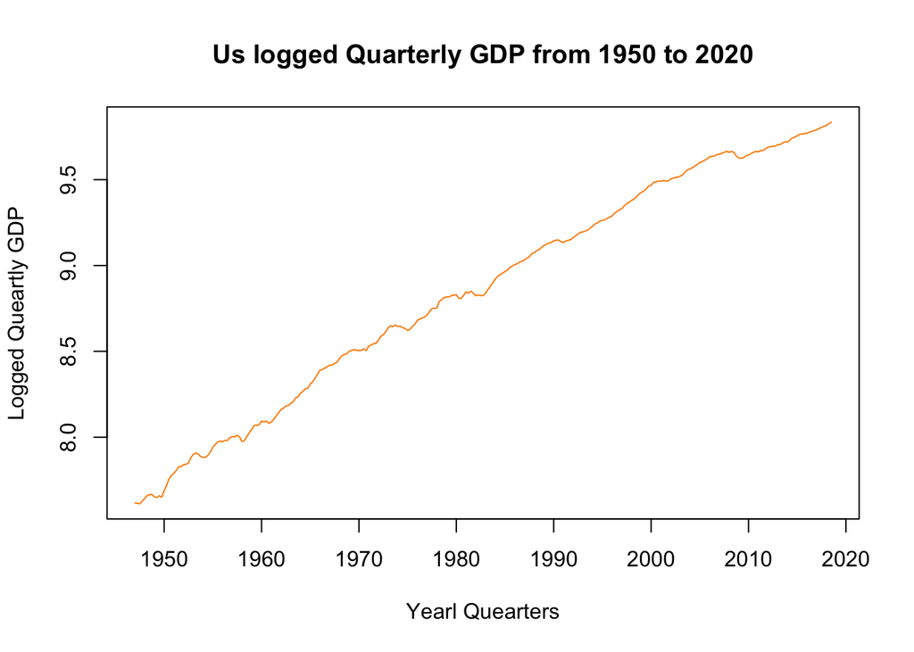

```r
# Takaing the log of the data
log_gdp = log(gdp)
# plotting the logged data
plot.ts(log_gdp, xlab = "Yearl Quearters", ylab = "Logged Queartly GDP",
        main = "Us logged Quarterly GDP from 1950 to 2020", col = "darkorange")
```

We can clearly see from the above plot, that the data has an upward trend. Therefore, the data is not stationary. To confirm this, we will plot the Auto-correlation function of the data.

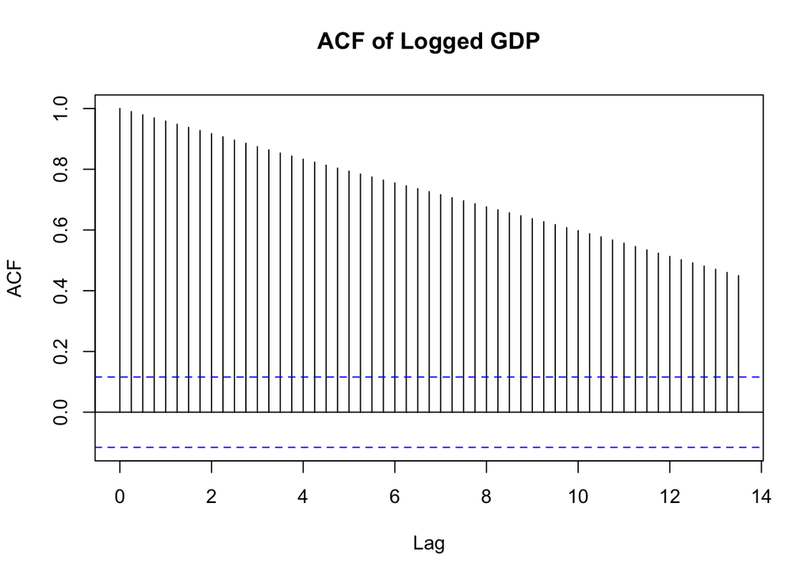

```r
# plotting the ACF of logged gdp data
acf(log_gdp, lag.max = 54, main = "ACF of Logged GDP")
```

The sample ACF, $\hat \rho(h)$ does to decay to zero fast enough as h, which is the time lag increases. This suggest the use of differencing transformation to remove non-stationarity of the data.

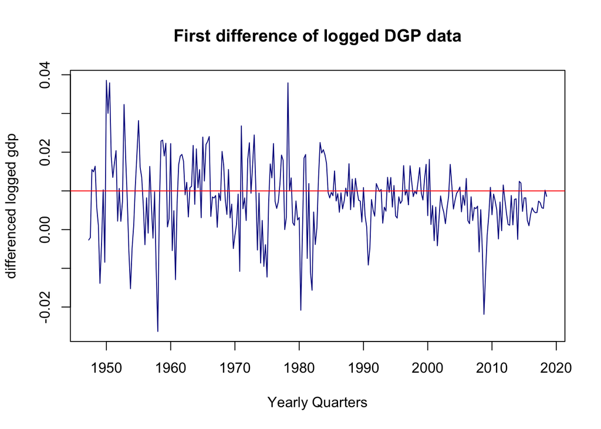

```r
# Taking the first difference of the logged data and plotting it.
plot(diff(log_gdp), xlab = "Yearly Quarters", ylab = "differenced logged gdp",
     main = "First difference of logged DGP data", col = "darkblue")
# Adding a line
abline(h = 0.01, col = "red")
```

From the plot of the differenced data, we can see the trend element of the data has been removed, and the data seems stationary.

We can plot the ACF and the PACF (Partial Auto-correlation function) of the differenced data to decide what models need to be fitted.

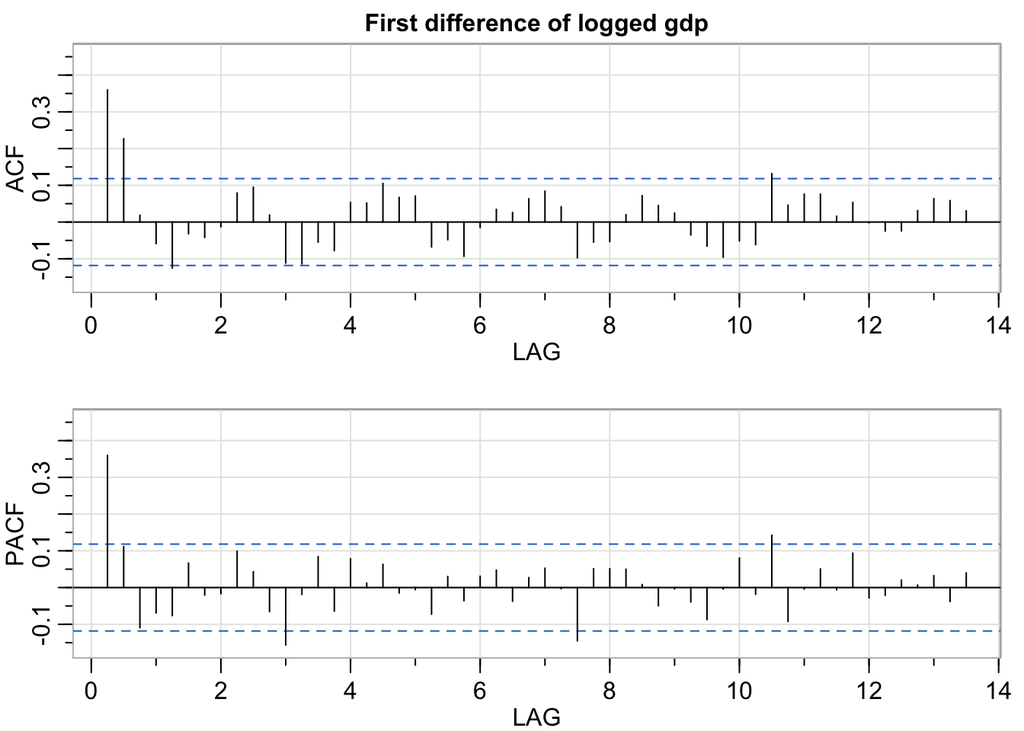

```r
# plots of ACF and PACF of differenced data
P_acf = acf2(diff(log_gdp), max.lag = 54, main = "First difference of logged gdp")
```

From the two plots above, it seems that PACF cuts of at lag 1 and ACF tails off at lag1. This suggests ARIMA(1, 1, 0) model for the logged data. We can also argue that ACF cuts of at lag 2 and PACF tails off at lag 2. This suggest ARIMA(0, 1, 2) for the logged data.

## Fitting ARIMA models

[figure not shown]

[figure not shown]

```r
white_noise = rnorm(150,0, 0.1)
plot.ts(white_noise)
```

ACF residuals are within the blue lines. This suggest, there is no serial correlation of the residuals at different lags. We can see almost all of ACF residuals fall within $2/(\sqrt{n})$ where $n$ is th lenght of our dataset. This is given by 0.1180563

From Normal Q-Q plot of the std Residuals, we see that most of the residuals are normally distributed except may be few outliers at the two ends.

However, We can see that most of the p-value for **Ljung-Box statistic** are within a significance level of 5%. Therefore, we will not reject the hypothesis that the residuals have some serial correlation (if most of the p-vluess are on or below the blue line, there is indication of autocorrelation).

```r
#coefficents and their p-values
AR1$ttable
```

```
##          Estimate     SE t.value p.value
## ar1        0.3603 0.0551  6.5365       0
## constant   0.0077 0.0008  9.5915       0
```

We can see that the p-value fo the coefficiens and the constant term are both significant.